# Tree-based ML and Feature Selection

**This week, your assignment is:**

- use our prepared churn data from week 2
- break our data into features and targets, and train and test sets
- use sklearn to fit a decision tree to the training data
  - plot the decision tree
  - change the max_depth of the decision tree to improve the model if needed (or tune it with a hyperparameter search)
- plot the correlations between features and targets
- use sklearn to fit a random forest model to predict churn from our dataset
  - plot the feature importances from the random forest
- choose some of the less-important features to remove from the model using feature importances and correlations and fit the random forest model to the new data
  - examine the feature importances after removing less important features
- write a short analysis of the results of your work

*Optional* advanced tasks:

- use H2O to fit a random forest to our original, unmodified data (missing values and all)
  - you can decide if you want to break the data into train and test sets or not, but remember it's best to evaluate performance on a test or validation dataset
  - plot the H2O random forest's feature importances
- tune the random forest hyperparameters for the sklearn and/or H2O models
- use forward and/or backward selection with feature importances from a random forest model
- use recursive feature selection
- compare the various feature selection methods you tried and write a short summary

```python
import pandas as pd
from sklearn.tree import DecisionTreeClassifier, plot_tree
from sklearn.model_selection import train_test_split
import matplotlib.pyplot as plt
```

```python
df=pd.read_csv('prepped_Churn_data.csv', index_col='customerID')
df
```

| customerID | Unnamed: 0 | tenure | PhoneService | Contract | PaymentMethod | MonthlyCharges | TotalCharges | Churn | totalcharges_monthlycharges_ratio | totalcharges_tenure_ratio |
| --- | --- | --- | --- | --- | --- | --- | --- | --- | --- | --- |
| 7590-VHVEG | 0 | 1 | 0 | 0 | 1 | 29.85 | 29.85 | 0 | 1.000000 | 29.850000 |
| 5575-GNVDE | 1 | 34 | 1 | 1 | 2 | 56.95 | 1889.50 | 0 | 33.178227 | 55.573529 |
| 3668-QPYBK | 2 | 2 | 1 | 0 | 2 | 53.85 | 108.15 | 1 | 2.008357 | 54.075000 |
| 7795-CFOCW | 3 | 45 | 0 | 1 | 3 | 42.30 | 1840.75 | 0 | 43.516548 | 40.905556 |
| 9237-HQITU | 4 | 2 | 1 | 0 | 1 | 70.70 | 151.65 | 1 | 2.144979 | 75.825000 |
| ... | ... | ... | ... | ... | ... | ... | ... | ... | ... | ... |
| 6840-RESVB | 7038 | 24 | 1 | 1 | 2 | 84.80 | 1990.50 | 0 | 23.472877 | 82.937500 |
| 2234-XADUH | 7039 | 72 | 1 | 1 | 4 | 103.20 | 7362.90 | 0 | 71.345930 | 102.262500 |
| 4801-JZAZL | 7040 | 11 | 0 | 0 | 1 | 29.60 | 346.45 | 0 | 11.704392 | 31.495455 |
| 8361-LTMKD | 7041 | 4 | 1 | 0 | 2 | 74.40 | 306.60 | 1 | 4.120968 | 76.650000 |
| 3186-AJIEK | 7042 | 66 | 1 | 2 | 3 | 105.65 | 6844.50 | 0 | 64.784666 | 103.704545 |

7032 rows × 10 columns

```python
df = df.drop('Unnamed: 0', axis=1)
df
```

| customerID | tenure | PhoneService | Contract | PaymentMethod | MonthlyCharges | TotalCharges | Churn | totalcharges_monthlycharges_ratio | totalcharges_tenure_ratio |
| --- | --- | --- | --- | --- | --- | --- | --- | --- | --- |
| 7590-VHVEG | 1 | 0 | 0 | 1 | 29.85 | 29.85 | 0 | 1.000000 | 29.850000 |
| 5575-GNVDE | 34 | 1 | 1 | 2 | 56.95 | 1889.50 | 0 | 33.178227 | 55.573529 |
| 3668-QPYBK | 2 | 1 | 0 | 2 | 53.85 | 108.15 | 1 | 2.008357 | 54.075000 |
| 7795-CFOCW | 45 | 0 | 1 | 3 | 42.30 | 1840.75 | 0 | 43.516548 | 40.905556 |
| 9237-HQITU | 2 | 1 | 0 | 1 | 70.70 | 151.65 | 1 | 2.144979 | 75.825000 |
| ... | ... | ... | ... | ... | ... | ... | ... | ... | ... |
| 6840-RESVB | 24 | 1 | 1 | 2 | 84.80 | 1990.50 | 0 | 23.472877 | 82.937500 |
| 2234-XADUH | 72 | 1 | 1 | 4 | 103.20 | 7362.90 | 0 | 71.345930 | 102.262500 |
| 4801-JZAZL | 11 | 0 | 0 | 1 | 29.60 | 346.45 | 0 | 11.704392 | 31.495455 |
| 8361-LTMKD | 4 | 1 | 0 | 2 | 74.40 | 306.60 | 1 | 4.120968 | 76.650000 |
| 3186-AJIEK | 66 | 1 | 2 | 3 | 105.65 | 6844.50 | 0 | 64.784666 | 103.704545 |

7032 rows × 9 columns

```python
#Here we are creating features and targets and also the train ans test sets
features = df.drop('Churn', axis=1)
targets = df['Churn']

x_train, x_test, y_train, y_test = train_test_split(features, targets, stratify=targets, random_state=42)
```

```python
dt = DecisionTreeClassifier()
dt.fit(x_train, y_train)

print(dt.score(x_train, y_train))
print(dt.score(x_test, y_test))
```

```
0.9945013272658324
0.7076222980659841
```

```python
dt.get_depth()
```

```
27
```

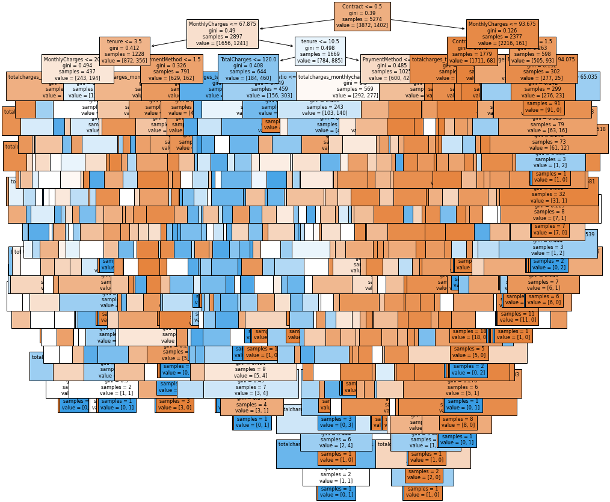

```python
f = plt.figure(figsize=(15, 15))
_ = plot_tree(dt, fontsize=8, feature_names=features.columns, filled=True)
```

```python
dt = DecisionTreeClassifier(max_depth=2)
dt.fit(x_train, y_train)

print(dt.score(x_train, y_train))
print(dt.score(x_test, y_test))
```

```
0.7533181645809632
0.742320819112628
```

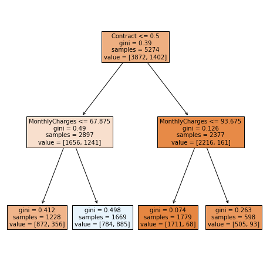

```python
f = plt.figure(figsize=(8, 8))
_ = plot_tree(dt, fontsize=10, feature_names=features.columns, filled=True)
```

```python
from sklearn.ensemble import RandomForestClassifier

rfc = RandomForestClassifier(max_depth=5, random_state=42)
rfc.fit(x_train, y_train)

print(rfc.score(x_train, y_train))
print(rfc.score(x_test, y_test))
```

```
0.8090633295411452
0.7940841865756542
```

```python
from sklearn.ensemble import RandomForestClassifier

rfc = RandomForestClassifier(max_depth=2, random_state=42)
rfc.fit(x_train, y_train)

print(rfc.score(x_train, y_train))
print(rfc.score(x_test, y_test))
```

```
0.7773985589685248
0.773037542662116
```

```python
import math

math.sqrt(x_train.shape[1])
```

```
2.8284271247461903
```

```python
from sklearn.ensemble import RandomForestClassifier

rfc = RandomForestClassifier(max_depth=2, max_features=7, random_state=42)
rfc.fit(x_train, y_train)

print(rfc.score(x_train, y_train))
print(rfc.score(x_test, y_test))
```

```
0.7901023890784983
0.782707622298066
```

# Feature selection

```python
import seaborn as sns
```

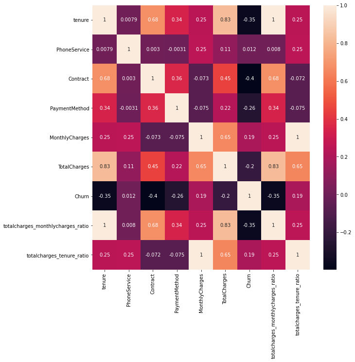

```python
f = plt.figure(figsize=(10, 10))
sns.heatmap(df.corr(), annot=True)
```

# Feature importances

```python
pip install scikit-plot
```

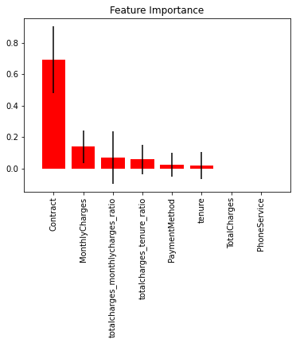

```python
from scikitplot.estimators import plot_feature_importances

plot_feature_importances(rfc, feature_names=features.columns, x_tick_rotation=90)
```

```python
new_features = features.drop(['TotalCharges','PhoneService'], axis=1)

x_train, x_test, y_train, y_test = train_test_split(new_features, targets, stratify=targets, random_state=42)
```

```python
rfc = RandomForestClassifier(max_depth=2, max_features=5, random_state=42)
rfc.fit(x_train, y_train)

print(rfc.score(x_train, y_train))
print(rfc.score(x_test, y_test))
```

```
0.7908608266970042
0.7866894197952219
```

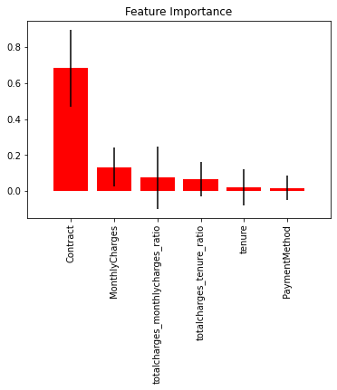

```python
plot_feature_importances(rfc, feature_names=new_features.columns, x_tick_rotation=90)
```

# Summary

[output not shown]